# R and RStudio Intro

13/04/2022

## This Demo

- Rmarkdown: cloned from https://github.com/micha-silver/ReLTER_demo
- Slides on website: https://micha-silver.github.io/index.html
- Youtube videos: (*to be announced*)

## Beginning with RStudio and git

[figure not shown]

New Project -> Version Control

Encourages collaboration “out of the box”.

https://github.com/micha-silver/ReLTER_demo

#### Basics of git:

- https://git-scm.com/book/en/v2/Git-Basics-Getting-a-Git-Repository
- https://r-bio.github.io/intro-git-rstudio/

#### Some online resources

- R for Data Science: https://r4ds.had.co.nz/index.html
- FasteR: https://github.com/matloff/fasteR
- Rseek: https://rseek.org/

#### RStudio hints

- Always work in an R project
- Use a git repo for collaboration
- Do **not** `setwd()`
- Do **not save workspace** to `.Rdata`
- Use Control+Shift+F10 often

#### Markdown versus `R` script

- Code is the same
- RMarkdown adds formatted text and outputs
- RMarkdown can produce output in html, pdf, and slides
- Perfect for reports and … demos

## Where to get `R` packages

- CRAN: https://cran.r-project.org/
- BioConductor: https://www.bioconductor.org/install/
- Packages developed on github, i.e. `ReLTER`

#### Installing packages

```r
# Install some standard spatial packages from CRAN
if (!require("sf", quietly = TRUE))
  install.packages("sf")
if (!require("terra", quietly = TRUE))
  install.packages("terra")

# package from Bioconductor
if (!require("BiocManager", quietly = TRUE))
  install.packages("BiocManager")
BiocManager::install()
BiocManager::install("EBImage")
```

#### Installing from github

```r
# Install development package from github
if (!require("remotes", quietly = TRUE))
  install.packages("remotes")

if (!require("ReLTER", quietly = TRUE))
  remotes::install_github("ropensci/ReLTER")
```

## Loading packages

After installing, we need to load the packages into this `R` session.

```r
# Convenient way to load list of packages
pkg_list <- c("sf", "terra", "ReLTER", "tmap")
lapply(pkg_list, require, character.only = TRUE)
```

```
## [[1]]
## [1] TRUE
##
## [[2]]
## [1] TRUE
##
## [[3]]
## [1] TRUE
##
## [[4]]
## [1] TRUE
```

## R Spatial

#### Key packages

- Handling vector data: `sf`, `terra`
- Handling raster data: `terra`, `stars`
- Visualization: `tmap`, `leaflet`, `ggmap`, (`plot`)
- Old, deprecated packages: sp, rgdal, raster, rgeos

#### Online resources

- Geocomputation with R: https://geocompr.robinlovelace.net/
- Spatial Data Science: https://www.rspatial.org/
- A blog on R-spatial issues: https://r-spatial.org/
- Packages are maintained here: https://github.com/rspatial

#### An initial example

Use the `geodata` package for sample data. Get administrative boundaries (from GADM) and monthly precipitation rasters (from WorldClim) for Slovakia.

```r
remotes::install_github("rspatial/geodata")
```

```r
library(geodata)
slv <- gadm("Slovakia", level=2, path=tempdir())
# Convert to `sf` for plotting
slv <- st_as_sf(slv)
slv_precip <- worldclim_country("Slovakia",
                                var = "prec", path = tempdir())
```

Display the data with `tmap`

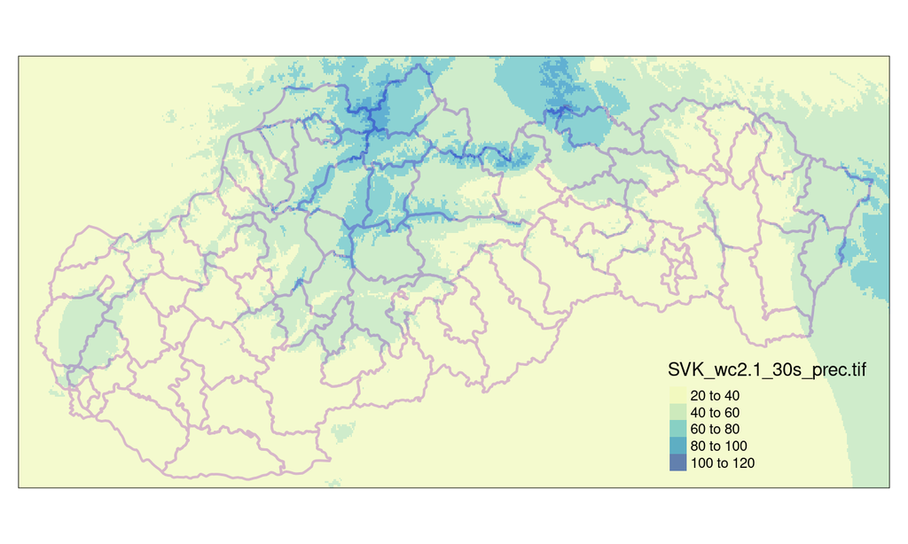

```r
# Use OpenStreetMaps as background
tm_basemap("OpenStreetMap.Mapnik") +
  tm_shape(slv) +
  tm_borders(col = "purple", lwd = 2) +
  tm_shape(slv_precip$SVK_wc2.1_30s_prec_1) +
  tm_raster(palette = "YlGnBu", alpha=0.7)
```

Now a different month

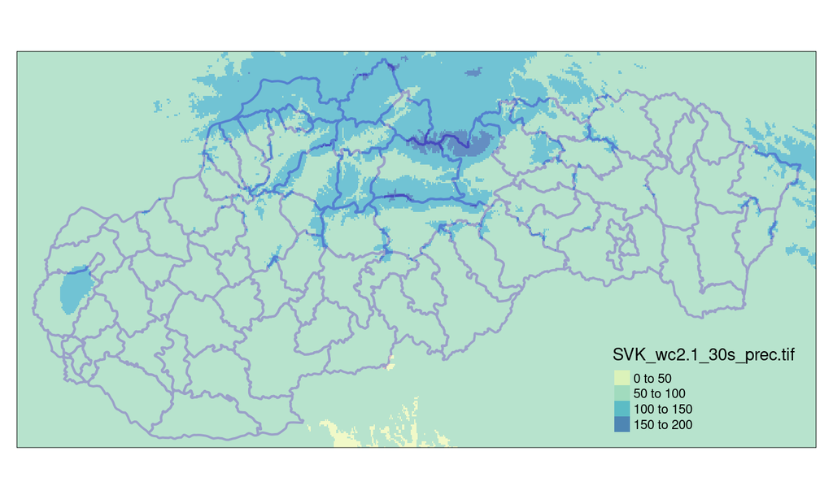

```r
tm_basemap("OpenStreetMap.Mapnik") +
  tm_shape(slv) +
  tm_borders(col = "purple", lwd = 2) +
  tm_shape(slv_precip$SVK_wc2.1_30s_prec_8) +
  tm_raster(palette = "YlGnBu", alpha=0.7)
```